# EP09-respuesta-equipo-8

2026-01-07

Para garantizar la reproducibilidad del estudio, se fijó una semilla aleatoria correspondiente a los últimos cuatro dígitos del RUN del integrante de menor edad (Semilla: 9253). Dado que la semilla resultó ser un número impar, se procedió a filtrar el conjunto de datos original para trabajar exclusivamente con la subpoblación de hombres (Gender = 1).

```r
set.seed(9253)
```

A partir de este subconjunto, se extrajo una muestra aleatoria de 100 observaciones. Posteriormente, se realizó una partición de los datos dividiéndolos en dos conjuntos: un set de entrenamiento constituido por 70 casos para la construcción de los modelos, y un set de validación de 30 casos para evaluar el desempeño predictivo en datos no vistos.

```r
set.seed(9253)
# Obtener el conjunto de datos
library(dplyr)
data <- read.csv2("EP09 Datos.csv")
datah <- data %>%
  filter(Gender == 1) %>%
  slice_sample(n = 100)
head(datah)
```

```
##   Biacromial.diameter Biiliac.diameter Bitrochanteric.diameter Chest.depth
## 1                37.1             24.2                    30.6        17.7
## 2                38.8             27.2                    31.6        18.5
## 3                41.1             23.0                    29.4        21.8
## 4                38.9             26.8                    31.5        20.4
## 5                41.3             29.0                    32.2        25.2
## 6                38.0             27.1                    28.3        18.2
##   Chest.diameter Elbows.diameter Wrists.diameter Knees.diameter Ankles.diameter
## 1           27.8            13.8            11.0           17.8            14.6
## 2           25.5            13.4            10.8           19.0            14.0
## 3           30.6            15.0            10.8           19.3            14.5
## 4           29.0            13.6            10.8           18.9            15.2
## 5           30.8            14.4            11.0           19.7            15.8
## 6           25.9            13.8            11.0           18.9            14.8
##   Shoulder.Girth Chest.Girth Waist.Girth Navel.Girth Hip.Girth Thigh.Girth
```

[output cut: 20 more lines]

```r
# Obtener los grupos de entrenamiento y validación
indicesEntrenamiento <- sample(1:100, 70)
dataConstruccion <- datah[indicesEntrenamiento, ]
dataValidacion <- datah[-indicesEntrenamiento, ]
```

Se seleccionaron aleatoriamente ocho variables candidatas a predictores: Bitrochanteric.diameter, Elbows.diameter, Waist.Girth, Chest.diameter, Wrists.diameter, Knee.Girth, Navel.Girth y Thigh.Girth.

```r
set.seed(9253)
columnNames <- colnames(data)

# Lista de variables quitando edad, peso, altura y género
columnList <- c("Biacromial.diameter", "Biiliac.diameter", "Bitrochanteric.diameter", "Chest.depth", "Chest.diameter" , "Elbows.diameter", "Wrists.diameter", "Knees.diameter", "Ankles.diameter", "Shoulder.Girth", "Chest.Girth", "Waist.Girth",   "Navel.Girth", "Hip.Girth", "Thigh.Girth", "Bicep.Girth", "Forearm.Girth", "Knee.Girth", "Calf.Maximum.Girth", "Ankle.Minimum.Girth", "Wrist.Minimum.Girth")

# Obtener las 8 variables aleatorias
variableAleatoria <- sample(columnList, 8)
print(variableAleatoria)
```

```
## [1] "Bitrochanteric.diameter" "Elbows.diameter"
## [3] "Waist.Girth"             "Knee.Girth"
## [5] "Chest.diameter"          "Navel.Girth"
## [7] "Wrists.diameter"         "Thigh.Girth"
```

Se seleccionó la variable Chest.Girth, ya que estudios antropométricos han demostrado que el grosor del pecho presenta una alta correlación con el peso corporal en hombres adultos. En particular, Garn (1983), en un estudio con más de 2.000 varones, evidencia que las medidas del tronco, asociadas al tamaño del tórax, explican mejor la variabilidad del peso corporal que la estatura, al reflejar de manera integrada la masa muscular y el tejido adiposo.

```r
m1 <- lm(Weight ~ Chest.Girth, data = dataConstruccion)
summary(m1)
```

```
##
## Call:
## lm(formula = Weight ~ Chest.Girth, data = dataConstruccion)
##
## Residuals:
##      Min       1Q   Median       3Q      Max
## -17.9776  -3.4844  -0.2864   3.3692  16.1028
##
## Coefficients:
##             Estimate Std. Error t value Pr(>|t|)
## (Intercept) -29.2166    10.1726  -2.872  0.00543 **
## Chest.Girth   1.0659     0.1014  10.517 6.68e-16 ***
## ---
## Signif. codes:  0 '***' 0.001 '**' 0.01 '*' 0.05 '.' 0.1 ' ' 1
##
## Residual standard error: 5.932 on 68 degrees of freedom
## Multiple R-squared:  0.6193, Adjusted R-squared:  0.6137
## F-statistic: 110.6 on 1 and 68 DF,  p-value: 6.683e-16
```

- Waist.Girth (Cintura)
- Elbows.diameter (Codos)
- Thigh.Girth (Muslo)
- Chest.diameter (Pecho)
- Knee.Girth (Rodilla)

Este modelo múltiple elevó significativamente la capacidad explicativa del peso, alcanzando un $R^2$ ajustado de 0.846, lo que sugiere un buen ajuste a los datos de entrenamiento.

```r
library(car)

# Revisar cuáles salieron en el muestreo aleatorio
print(variableAleatoria)
```

```
## [1] "Bitrochanteric.diameter" "Elbows.diameter"
## [3] "Waist.Girth"             "Knee.Girth"
## [5] "Chest.diameter"          "Navel.Girth"
## [7] "Wrists.diameter"         "Thigh.Girth"
```

```r
# Asegurar Waist.Girth en el conjunto de predictores (sin duplicados)
vars_max <- unique(c("Waist.Girth", variableAleatoria))

# Modelo máximo: Waist + las 8 variables aleatorias (si Waist salió, no se duplica)
form_max <- as.formula(paste("Weight ~", paste(vars_max, collapse = " + ")))
m_full <- lm(form_max, data = dataConstruccion)

# Modelo inicial: partir con Waist.Girth para que quede siempre incluido
m1 <- lm(Weight ~ Waist.Girth, data = dataConstruccion)

# Stepwise por AIC (Waist siempre presente porque está en lower)
m_step <- step(
  m1,
  scope = list(lower = formula(m1), upper = formula(m_full)),
  direction = "both",
  trace = FALSE
)

summary(m_step)
```

```
##
## Call:
## lm(formula = Weight ~ Waist.Girth + Elbows.diameter + Thigh.Girth +
##     Chest.diameter + Knee.Girth + Bitrochanteric.diameter, data = dataConstruccion)
##
## Residuals:
##     Min      1Q  Median      3Q     Max
## -7.3481 -2.5454  0.0182  2.5383  8.0314
##
## Coefficients:
##                          Estimate Std. Error t value Pr(>|t|)
## (Intercept)             -86.84189    9.96338  -8.716 2.01e-12 ***
## Waist.Girth               0.43949    0.07528   5.838 2.00e-07 ***
## Elbows.diameter           3.13572    0.63113   4.968 5.46e-06 ***
## Thigh.Girth               0.40957    0.17827   2.297   0.0249 *
## Chest.diameter            0.70552    0.26409   2.672   0.0096 **
## Knee.Girth                0.55206    0.29037   1.901   0.0618 .
## Bitrochanteric.diameter   0.53970    0.30520   1.768   0.0818 .
## ---
## Signif. codes:  0 '***' 0.001 '**' 0.01 '*' 0.05 '.' 0.1 ' ' 1
##
## Residual standard error: 3.684 on 63 degrees of freedom
## Multiple R-squared:  0.8639, Adjusted R-squared:  0.851
## F-statistic: 66.66 on 6 and 63 DF,  p-value: < 2.2e-16
```

```r
formula(m_step)
```

```
## Weight ~ Waist.Girth + Elbows.diameter + Thigh.Girth + Chest.diameter +
##     Knee.Girth + Bitrochanteric.diameter
```

```r
m5 <- lm(Weight ~ Waist.Girth + Elbows.diameter + Thigh.Girth +
Chest.diameter + Knee.Girth,
data = dataConstruccion)

summary(m5)
```

```
##
## Call:
## lm(formula = Weight ~ Waist.Girth + Elbows.diameter + Thigh.Girth +
##     Chest.diameter + Knee.Girth, data = dataConstruccion)
##
## Residuals:
##     Min      1Q  Median      3Q     Max
## -8.4229 -2.4849  0.2122  2.7750  7.4816
##
## Coefficients:
##                  Estimate Std. Error t value Pr(>|t|)
## (Intercept)     -80.45627    9.43904  -8.524 3.86e-12 ***
## Waist.Girth       0.48621    0.07165   6.785 4.42e-09 ***
## Elbows.diameter   3.39758    0.62363   5.448 8.68e-07 ***
## Thigh.Girth       0.43611    0.18057   2.415  0.01859 *
## Chest.diameter    0.74687    0.26739   2.793  0.00688 **
## Knee.Girth        0.57495    0.29486   1.950  0.05557 .
## ---
## Signif. codes:  0 '***' 0.001 '**' 0.01 '*' 0.05 '.' 0.1 ' ' 1
##
## Residual standard error: 3.745 on 64 degrees of freedom
## Multiple R-squared:  0.8572, Adjusted R-squared:  0.846
## F-statistic: 76.82 on 5 and 64 DF,  p-value: < 2.2e-16
```

Se verificaron las condiciones de validez para el modelo RLM:

Homocedasticidad: Se confirmó mediante el test de varianza no constante (ncvTest), obteniendo un valor-p de 0.43, lo que permite asumir varianza constante en los residuos.

Multicolinealidad: Se analizó el Factor de Inflación de la Varianza (VIF), observando que todos los predictores presentan valores bajos (VIF < 2.3), descartando problemas severos de colinealidad.

Casos Influyentes: Se examinaron los residuos estudentizados, el apalancamiento (leverage) y la distancia de Cook. Aunque se identificaron algunas observaciones con influencia alta (ej. observaciones 1, 9, 11, 18), se decidió mantener el modelo debido a su alta consistencia general y estabilidad en los supuestos estadísticos.

Supuestos basicos

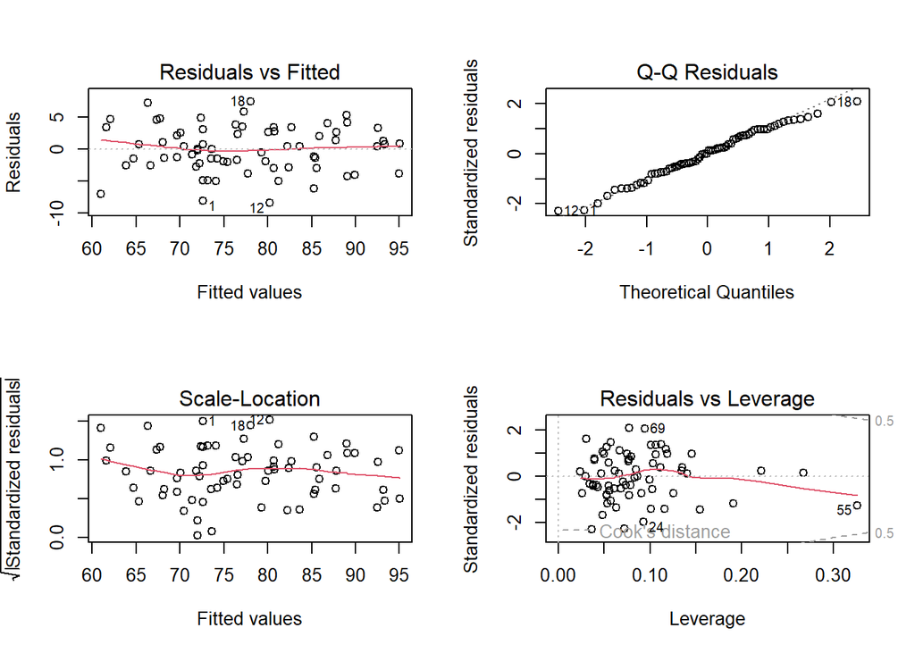

```r
par(mfrow = c(2,2))
plot(m5)
```

```r
par(mfrow = c(1,1))
```

Homocedasticidad

```r
library(car)
ncvTest(m5)
```

```
## Non-constant Variance Score Test
## Variance formula: ~ fitted.values
## Chisquare = 0.6195527, Df = 1, p = 0.43121
```

Multicolinealidad

```r
vif(m5)
```

```
##     Waist.Girth Elbows.diameter     Thigh.Girth  Chest.diameter      Knee.Girth
##        1.830631        1.323479        2.247556        1.772901        2.033129
```

Atípicos e influyentes

```r
n <- nrow(dataConstruccion)
p <- length(coef(m5))

stud <- rstudent(m5)
lev  <- hatvalues(m5)
cook <- cooks.distance(m5)

umbral_stud <- 3
umbral_lev  <- 2*p/n
umbral_cook <- 4/n

which(abs(stud) > umbral_stud)
```

```
## named integer(0)
```

```r
which(lev > umbral_lev)
```

```
## 11 37 55 41
## 31 47 61 64
```

```r
which(cook > umbral_cook)
```

```
##  1 18  9 69 55 24
## 10 20 21 60 61 67
```

Finalmente, se evaluó el modelo con los 30 datos reservados (set de validación). El modelo demostró una alta capacidad de generalización, obteniendo un Error Cuadrático Medio (RMSE) de 3.76 kg y un coeficiente de determinación ($R^2$) de 0.865 en los datos nuevos, confirmando que el modelo no presenta sobreajuste (overfitting) y es apto para realizar predicciones confiables.

```r
pred <- predict(m5, newdata = dataValidacion)
obs  <- dataValidacion$Weight

RMSE <- sqrt(mean((obs - pred)^2))
MAE  <- mean(abs(obs - pred))
R2   <- 1 - sum((obs - pred)^2) / sum((obs - mean(obs))^2)

RMSE
```

```
## [1] 3.761813
```

```r
MAE
```

```
## [1] 3.261473
```

```r
R2
```

```
## [1] 0.8656667
```

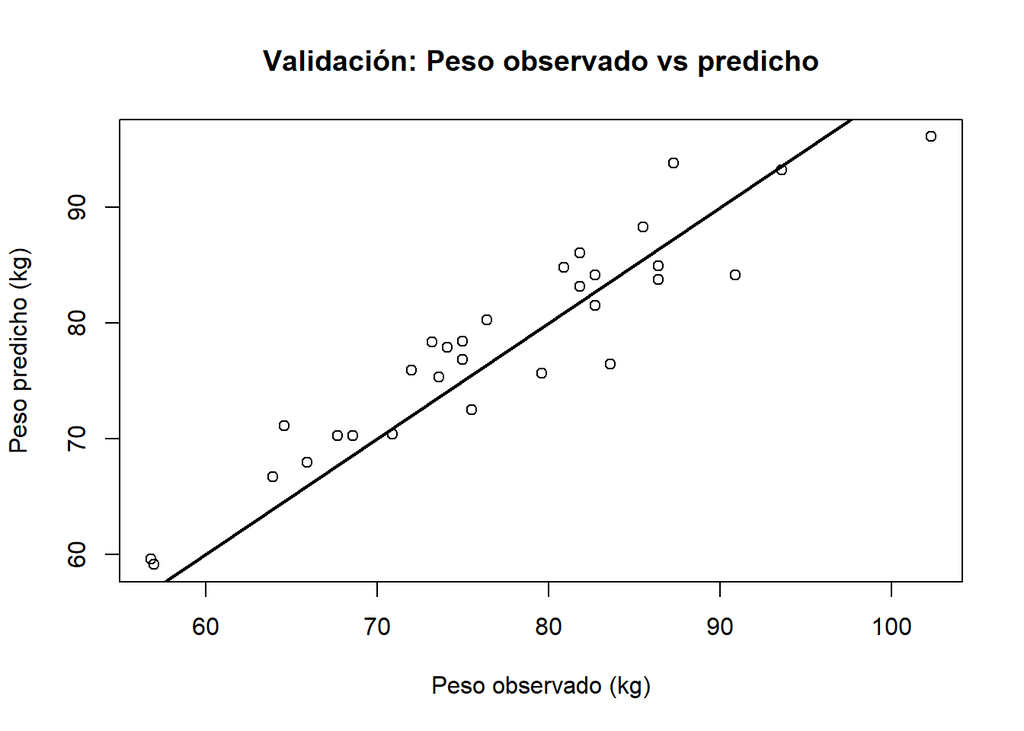

```r
plot(obs, pred,
xlab = "Peso observado (kg)",
ylab = "Peso predicho (kg)",
main = "Validación: Peso observado vs predicho")
abline(0, 1, lwd = 2)
```

# Conclusión

Después de leer y filtrar el conjunto de datos, seleccionando un grupo para crear el modelo y otro para validarlo, y crear un modelo de RLS y RLM, se puede concluir que el modelo final cumple con el objetivo de predecir la variable del peso de los hombres. En específico, el modelo puede explicar un 86% la variabilidad en la variable del peso, y además cumple con las condiciones de generalidad para un modelo RLM, lo que significa calidad y confiabilidad. Finalmente, las variables elegidas para el modelo de regresión lineal múltiple construido son capaces de predecir con suficiente exactitud la variable del peso de los hombres.

# Lista de referencias

- Garn, S. M. (1983). The bony chest breadth as a frame size standard in nutritional assessment. American Journal of Physical Anthropology, 61(2), 193–198. https://pubmed.ncbi.nlm.nih.gov/6823896/